# Практические рекомендации по линейным моделям

## Масштабирование признаков

### Первый способ - стандартизация

Для начала необходимо вычислить средние значения признаков и стандартные отклонения:

$$\Large \mu_j = \frac{1}{\ell}\sum_{i=1}^l x_i^j$$$$\sigma_j = \sqrt{\frac{1}{\ell}\sum^l_{i=1}(x_i^j-\mu_j)^2}$$

Стандартизация признака:

$$\Large x_i^j = \frac{x_i^j - \mu_j}{\sigma_j}$$

После того, как это будет выполнено для всех признаков, сдвиги и различия в масштабах будут убраны

### Второй способ - масштабирование на отрезок [0;1]

Необходимо вычислить максимальное и минимальное значение каждого признака:

$$\Large m_j=min(x_1^j,...,x_n^j)$$$$\Large M_j=max(x_1^j,...,x_n^j)$$

После этого значение каждого признака на конкретном объекте преобразовывается следующим образом:

$$\Large x_i^j = \frac{x_i^j - m_j}{M_j-m_j}$$

Тогда минимальное значение признака отображается в ноль, а максимальное — в 1, то есть признаки масштабируются на отрезок [0, 1].

## Нелинейные зависимости

В этом разделе речь пойдет о спрямляющих пространствах, которые позволяют восстанавливать нелинейные зависимости с помощью линейных моделей.

*Спрямляющим пространством признаков называется такое пространство, в котором задача хорошо решается линейной моделью.*

Спрямляющее пространство может, в том числе, быть построено:

*• Через добавление квадратичных признаков, то есть когда к исходным признакам добавляются их квадраты и попарные произведения:*

$(x_1, ..., x_d) → (x_1, ..., x_d, x_{21}, ..., x_{2d}, x_1x_2, ..., x_{d−1}x_d).$

Следует особо отметить, что в таком случае число признаков увеличивается на порядок. Если объектов не слишком много, существует риск переобучения в таком большом признаковом пространстве.

*• Через добавление полиномиальных признаков:*

$(x_1, ..., x_d) → (x_1, ..., x_d, ..., x_ix_j , ..., x_ix_jx_k, ...).$

Этот способ следует использовать только, когда объектов достаточно много, то есть риск переобучения минимален, а также заранее известно, что зависимости очень нелинейные.

*• Через логарифмирование (или любые другие нелинейные функции):*

$x_i → ln(x_i + 1), x_i → ln(|x_i| + 1).$

## Работа с категориальными признаками

Особенность категориальных признаков состоит в том, что это элементы некоторого неупорядоченного множества, и нельзя говорить, что какое-то значение больше или меньше другого. Можно только сравнивать их на равенство. Но в линейных моделях нужно брать значение признака, умножать на вес, а потом складывать с другими числами, и эту операцию нельзя делать со значениями категориальных признаков. Категориальные признаки нужно сначала преобразовать, чтобы их можно было использовать в линейных моделях.

### Бинарное кодирование

Один из наиболее популярных подходов к кодированию категориальных признаков — бинарное кодирование. Далее будут использоваться следующие обозначения. Пусть $j$-ый признак — категориальный и принимает $n$ возможных значений:

$c_1, ..., c_n$.

Пусть также $f_j(x)$ — значение этого признака на объекте $x$. Чтобы закодировать данный признак, вводятся n новых бинарных признаков:

$b_1(x), ..., b_n(x),$

причем значение бинарного признака $b_i$ равно единице только в том случае, если на данном объекте $x$ значение категориального признака $f_j (x)$ равно $c_i$:

$b_i(x) = [f_j(x) = c_i].$

В результате один категориальный признак заменяется $n$ бинарными признаками

Пусть в качестве признака рассматривается цвет, причем он может принимать три значения: синий, зеленый или красный. Дано три объекта $x_1, x_2, x_3$, на которых значения категориального признака:

$f_j (x_1) = синий, f_j (x_2) = красный, f_j (x_3) = синий.$

Поскольку категориальный признак принимает 3 значения, потребуется 3 бинарных признака, чтобы его закодировать. В результате получается следующая матрица (каждому объекту соответствует своя строка, а каждому столбцу — свое значение признака):

1 0 0

0 0 1

1 0 0

## Несбалансированные данные

Пусть решается задача классификации с несбалансированной выборкой. Задача называется несбалансированной, если объектов одного класса существенно меньше, чем объектов остальных классов. Например, задача бинарной классификации называется несбалансированной, если объектов одного из двух классов менее 10%.

Основная проблема, связанная с несбалансированными выборками, состоит в том, что классификаторы минимизируют число неправильных ответов и никак не учитывают цены ошибок. Может возникнуть ситуация, когда выгоднее отнести все объекты к большему классу, не пытаясь как-то выделить объекты маленького класса. Другими словами, при работе с несбалансированными выборками классификаторы получаются очень плохие с точки зрения точности или полноты.

### Undersampling

Первый подход к работе с несбалансированными выборками — undersampling. Его основная идея состоит в том, что часть объектов из большого класса выбрасываются из выборки. Пусть, например, есть три класса: очень крупный, крупный и небольшой

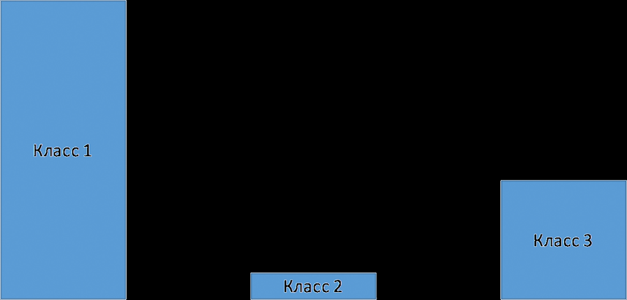

В этом случае необходимо выкинуть большую часть 1го класса и половину объектов 3го класса. Размеры классов примерно сравняются.

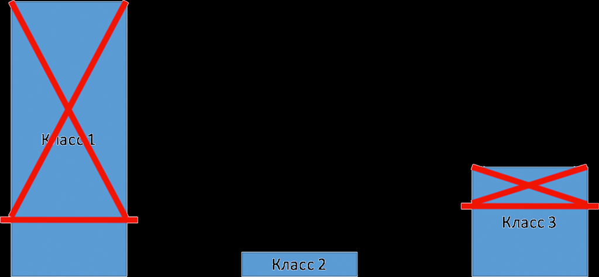

При этом то, сколько именно объектов каждого класса выбрасывается — это гиперпараметр, который имеет смысл настраивать по отложенной выборке или по кросс-валидации.

### Oversampling

Второй подход, oversampling, противоположен предыдущему: в данном случае объекты маленьких классов дублируются, чтобы выравнять соотношение классов.

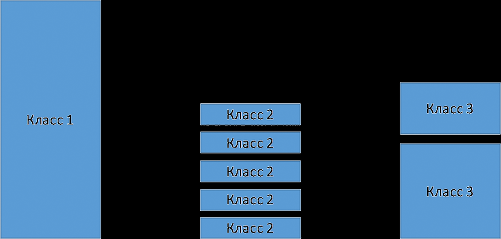

В предыдущем примере 5 раз необходимо продублировать объекты 2го класса, а также продублировать случайную половину 3го класса. В этом случае размеры классов тоже выравняются. То, на сколько будет увеличен каждый класс — тоже гиперпараметр.

Следует обратить внимание на одну особенность. Если задача решается на исходной выборке, то средне- квадратичная ошибка выглядит:

$$\Large MSE(a, X) = \frac{1}{\ell}\sum_{i=1}^l(a(x_i) - y_i)^2$$

Но если делается oversampling, то есть дублируются какие-нибудь объекты, некоторые слагаемые будут вхо- дить в эту сумму несколько раз. Таким образом, вместо реального дублирования объектов, можно выставить соответствующие веса $v_i$:

$$\Large MSE(a,X) = \frac{1}{\ell}\sum_{i=1}^lv_i(a(x_i)-y_i)^2$$

### Стратификация

Еще одна проблема, с которой можно столкнуться при работе с несбалансированными выборками, заклю- чается в том, что при проведении кросс-валидации исходная выборка разбивается на k блоков примерно одинаковой длины. При этом, **если выборка несбалансированная, может получиться ситуация, что в некото- рые блоки объекты какого-то класса не попадут вообще. Такая ситуация крайне неприятна: при обучении на этом блоке получается классификатор, который никогда не видел один из классов.**

*Чтобы с этим бороться необходимо использовать стратификацию, то есть делать так, чтобы распределение классов в каждом блоке примерно совпадало с распределением классов в исходной выборке. В этом случае будет гарантироваться, что объекты каждого из классов будут представлены в каждом из блоков разбиения.*

## Многоклассовая классификация

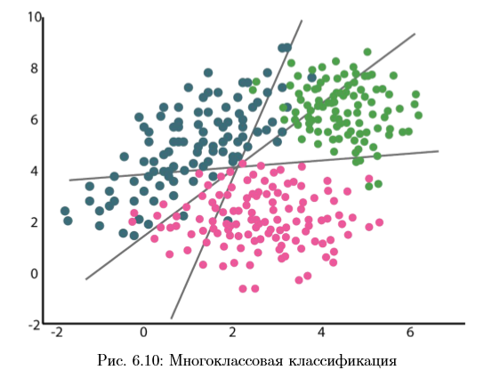

**В случае бинарной классификации подход был простой, нужно было найти такой вектор весов $w$, что выражение $a(x)=sign(<w,x>)$ определяло бы к какому классу отнести объект**

### ONE-VS-ALL

Этот метод можно расширить для многоклассовой классификации. Этот метод называется ONE-VS-ALL. Для каждого класса будет строиться свой бинарный классификатор

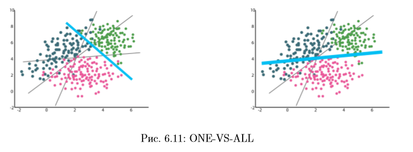

Формально говоря, будет решаться K-задача бинарной классификации:

$$\Large X = (x_i, [y_i=k])^{\ell}_{i=1}$$

Объекты $x_i$ остаются такими же, а ответы становятся бинарными. Будет построен некоторый бинарный классификатор, который отделяет k-класс от всех остальных:

$$\Large a_k(x) = sign(<w_k, x>)$$

*Если знак скалярного произведения положительный, то чем больше его модуль, тем больше классификатор уверен в том, что объект относится к определенному классу.* Поэтому для построения многоклассового классификатора можно построить такой алгоритм:

$$\Large a(x) = argmax_{k\in 1,...,K}(<w_k, X>)$$

который будет возвращать тот класс $k$,для которого уверенность соответствующего классификатора(то есть значение соответствующего скалярного произведения) больше всего.

### Матрица ошибок

Для анализа того, насколько хорошо работает классификатор, удобно использовать матрицу ошибок. Каждая строка этой матрицы соответствует тем объектам, которые классификатор отнес к тому или иному классу. А столбец - истинная принадлежность класса.

Например, на пересечении первой строки и второго столбца стоит число $q_{12}$, которое показывает то, сколько объектов второго класса многоклассовый классификатор отнес к первому.

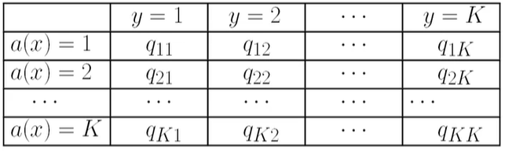